# Using dittoSeq to visualize (sc)RNAseq data

### 7.6.3 multi_dittoDimPlot & multi_dittoDimPlotVaryCells

`multi_dittoDimPlot()` creates dittoDimPlots for multiple genes or metadata, one plot each.

`multi_dittoDimPlotVaryCells()` creates dittoDimPlots for a single gene or metadata, but where distinct cells are highlighted in each plot. The `vary.cells.meta` input sets the discrete metadata to be used for breaking up cells/samples over distinct plots. This can be useful for checking/highlighting when a gene may be differentially expressed within multiple cell types or across all samples.

- The output of `multi_dittoDimPlotVaryCells()` is similar to that of faceting using dittoDimPlot’s `split.by` input, but with added capability of showing an “AllCells” plot as well, or of outputting the individual plots for making manually customized plot arrangements when `data.out = TRUE`.

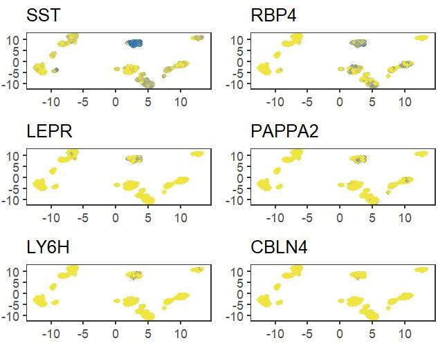

```r
multi_dittoDimPlot(sce, delta.genes[1:6])
```

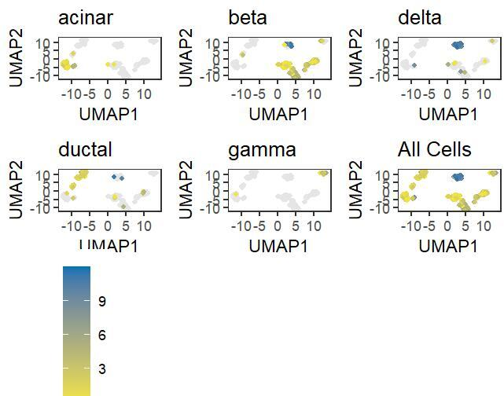

```r
multi_dittoDimPlotVaryCells(sce, delta.genes[1],
    vary.cells.meta = "label")
```

# 8 Customization via Simple Inputs

**Many adjustments can be made with simple additional inputs**. Here, we’ll go through a few that are consistent across most dittoSeq functions, but there are many more. Be sure to check the function documentation (e.g. `?dittoDimPlot`) to explore more! Often, there will be a dedicated section towards the bottom of a function’s documentation dedicated to its specific tweaks!

## 8.1 Subsetting to certain cells/samples

The cells/samples shown in a given plot can be adjusted with the `cells.use` input. This can be provided as either a list of cells’ / samples’ names to include, as an integer vector with the indices of cells to keep, or as a logical vector that states whether each cell / sample should be included.

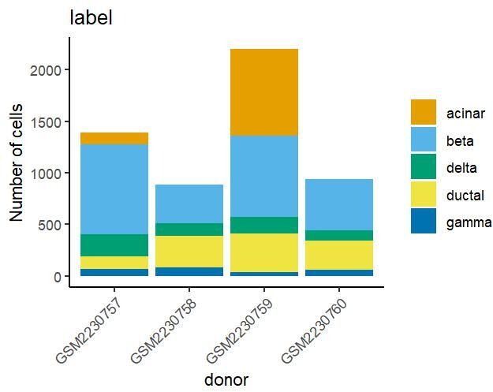

```r
# Original
dittoBarPlot(sce, "label", group.by = "donor", scale = "count")
```

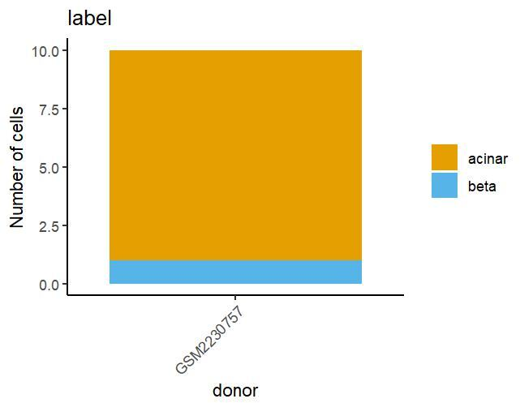

```r
# First 10 cells
dittoBarPlot(sce, "label", group.by = "donor", scale = "count",
    # String method
    cells.use = colnames(sce)[1:10]
    # Index method, which would achieve the same effect
    # cells.use = 1:10
    )
```

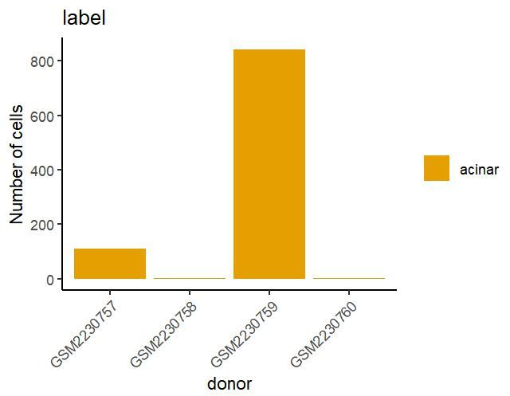

```r
# Acinar cells only
dittoBarPlot(sce, "label", group.by = "donor", scale = "count",
    # Logical method
    cells.use = meta("label", sce) == "acinar")
```

## 8.2 Faceting with split.by

Most diitoSeq plot types can be faceted into separate plots for distinct groups of cells with the `split.by` input.

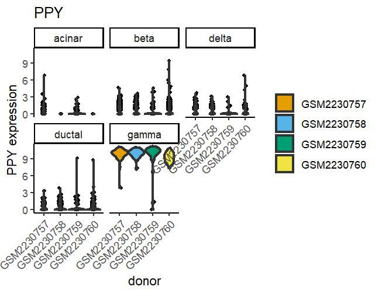

```r
dittoPlot(sce, "PPY", group.by = "donor",
    split.by = "label")
```

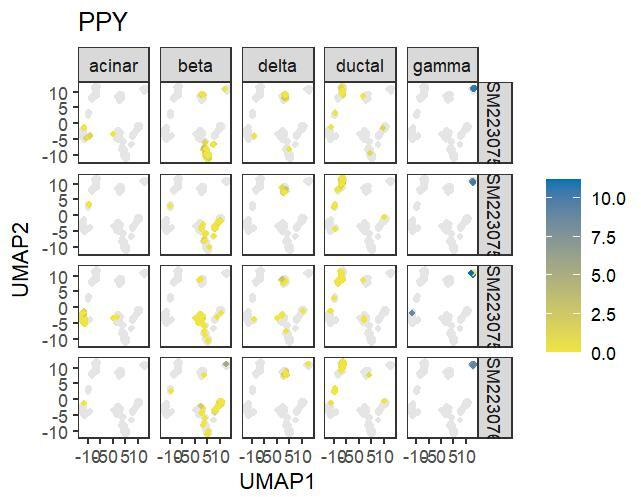

```r
dittoDimPlot(sce, "PPY",
    split.by = c("donor", "label"))
```

Extra control over how this is done can be achieved with the `split.adjust` input. `split.adjust` allows inputs to be passed through to the ggplot functions used for achieving the faceting.

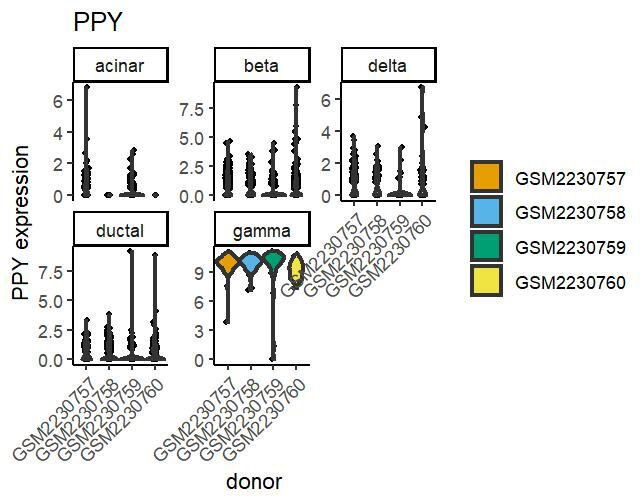

```r
dittoPlot(sce, "PPY", group.by = "donor",
    split.by = "label",
    split.adjust = list(scales = "free_y"), max = NA)
```

When splitting is by only one metadata, the shape of the facet grid can be controlled with `split.ncol` and `split.nrow`.

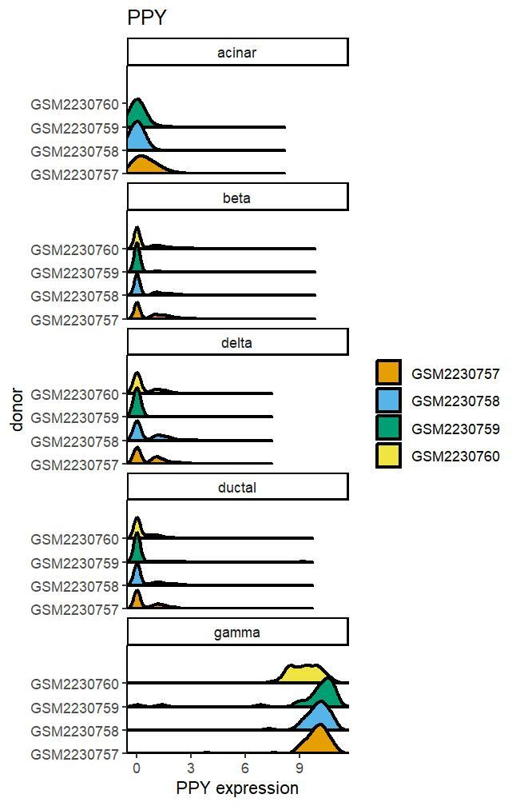

```r
dittoRidgePlot(sce, "PPY", group.by = "donor",
    split.by = "label",
    split.ncol = 1)
```

## 8.3 All titles are adjustable.

Relevant inputs are generally `main`, `sub`, `xlab`, `ylab`, `x.labels`, and `legend.title`.

[figure not shown]

```r
dittoBarPlot(sce, "label", group.by = "donor",
    main = "Encounters",
    sub = "By Type",
    xlab = NULL, # NULL = remove
    ylab = "Generation 1",
    x.labels = c("Ash", "Misty", "Jessie", "James"),
    legend.title = "Types",
    var.labels.rename = c("Fire", "Water", "Grass", "Electric", "Psychic"),
    x.labels.rotate = FALSE)
```

As exemplified above, in some functions, the displayed data can be renamed too.

## 8.4 Colors can be adjusted easily.

Colors are normally set with `color.panel` or `max.color` and `min.color`. When color.panel is used (discrete data), an additional input called `colors` sets the order in which those are actually used to make swapping around colors easy when nearby clusters appear too similar in tSNE/umap plots!

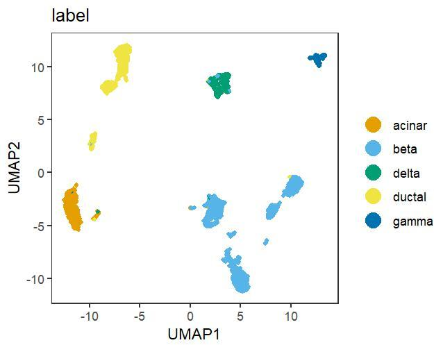

```r
# original - discrete
dittoDimPlot(sce, "label")
```

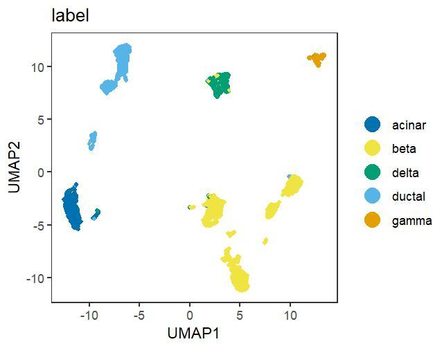

```r
# swapped colors
dittoDimPlot(sce, "label",
    colors = 5:1)
```

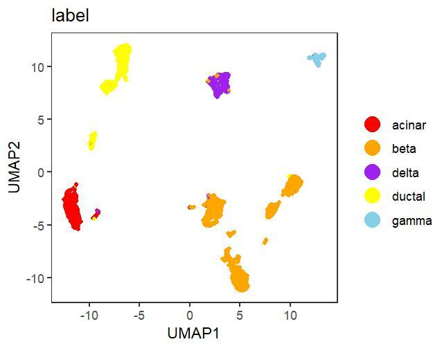

```r
# different colors
dittoDimPlot(sce, "label",
    color.panel = c("red", "orange", "purple", "yellow", "skyblue"))
```

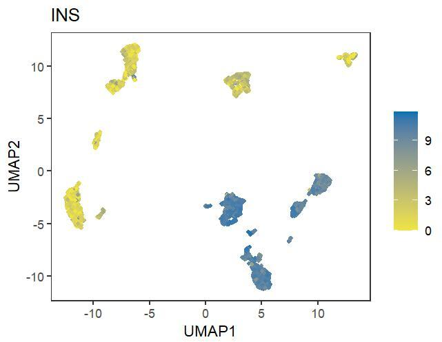

```r
# original - expression
dittoDimPlot(sce, "INS")
```

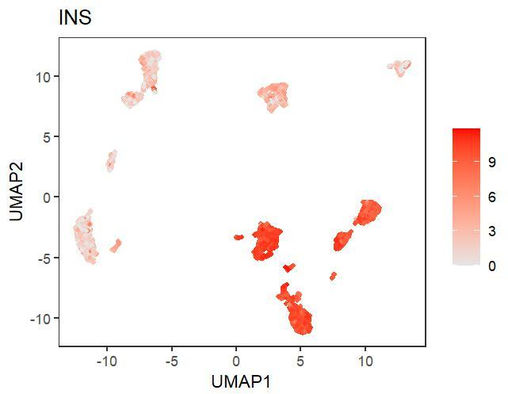

```r
# different colors
dittoDimPlot(sce, "INS",
    max.color = "red", min.color = "gray90")
```

## 8.5 Underlying data can be output.

Simply add `data.out = TRUE` to any of the individual plotters and a representation of the underlying data will be output.

```r
dittoBarPlot(sce, "label", group.by = "donor",
    data.out = TRUE)
```

```
##
## $data
##     label   grouping count label.count.total.per.facet     percent
## 1  acinar GSM2230757   110                        1386 0.079365079
## 2    beta GSM2230757   872                        1386 0.629148629
## 3   delta GSM2230757   214                        1386 0.154401154
## 4  ductal GSM2230757   120                        1386 0.086580087
## 5   gamma GSM2230757    70                        1386 0.050505051
## 6  acinar GSM2230758     3                         886 0.003386005
## 7    beta GSM2230758   371                         886 0.418735892
## 8   delta GSM2230758   125                         886 0.141083521
## 9  ductal GSM2230758   301                         886 0.339729120
## 10  gamma GSM2230758    86                         886 0.097065463
## 11 acinar GSM2230759   843                        2203 0.382660009
## 12   beta GSM2230759   787                        2203 0.357240127
## 13  delta GSM2230759   161                        2203 0.073082161
## 14 ductal GSM2230759   376                        2203 0.170676350
## 15  gamma GSM2230759    36                        2203 0.016341353
## 16 acinar GSM2230760     2                         941 0.002125399
## 17   beta GSM2230760   495                         941 0.526036132
## 18  delta GSM2230760   101                         941 0.107332625
## 19 ductal GSM2230760   280                         941 0.297555792
## 20  gamma GSM2230760    63                         941 0.066950053
```

For dittoHeatmap, a list of all the arguments that would be supplied to pheatmap are output. This allows users to make their own tweaks to how the expression matrix is represented before plotting, or even to use a different heatmap creator from pheatmap altogether.

```r
dittoHeatmap(sce, c("SST","CPE","GPX3"), cells.use = colnames(sce)[1:5],
    data.out = TRUE)
```

```
## $mat
##      human1_lib1.final_cell_0001 human1_lib1.final_cell_0002
## SST                     3.367669                   3.3376026
## CPE                     0.000000                   0.5530070
## GPX3                    0.000000                   0.3028399
##      human1_lib1.final_cell_0003 human1_lib1.final_cell_0004
## SST                    2.3925635                    3.018649
## CPE                    0.0000000                    0.000000
## GPX3                   0.4713904                    0.000000
##      human1_lib1.final_cell_0005
## SST                    3.4550443
## CPE                    0.9004598
## GPX3                   0.0000000
##
## $main
## [1] NA
##
## $show_colnames
## [1] FALSE
##
## $show_rownames
## [1] TRUE
##
## $color
##  [1] "#0000FF" "#0A0AFF" "#1414FF" "#1F1FFF" "#2929FF" "#3434FF" "#3E3EFF"
##  [8] "#4848FF" "#5353FF" "#5D5DFF" "#6868FF" "#7272FF" "#7C7CFF" "#8787FF"
## [15] "#9191FF" "#9C9CFF" "#A6A6FF" "#B0B0FF" "#BBBBFF" "#C5C5FF" "#D0D0FF"
## [22] "#DADAFF" "#E4E4FF" "#EFEFFF" "#F9F9FF" "#FFF9F9" "#FFEFEF" "#FFE4E4"
## [29] "#FFDADA" "#FFD0D0" "#FFC5C5" "#FFBBBB" "#FFB0B0" "#FFA6A6" "#FF9C9C"
## [36] "#FF9191" "#FF8787" "#FF7C7C" "#FF7272" "#FF6868" "#FF5D5D" "#FF5353"
## [43] "#FF4848" "#FF3E3E" "#FF3434" "#FF2929" "#FF1F1F" "#FF1414" "#FF0A0A"
## [50] "#FF0000"
##
## $cluster_cols
## [1] FALSE
##
## $border_color
## [1] NA
##
## $scale
## [1] "row"
##
## $breaks
## [1] NA
##
## $legend_breaks
## [1] NA
##
## $drop_levels
## [1] FALSE
```

## 8.6 plotly hovering can be added.

Many dittoSeq functions can be supplied `do.hover = TRUE` to have them convert the output into an interactive plotly object that will display additional data about each data point when the user hovers their cursor on top.

Generally, a second input, `hover.data`, is used to tell dittoSeq what extra data to display. This input takes in a vector of gene or metadata names (or “ident” for Seurat object clustering) in the order you wish for them to be displayed. However, when the types of underlying data possible to be shown are constrained because the plot pieces represent summary data (dittoBarPlot and dittoPlotVarsAcrossGroups), the `hover.data` input is not used.

```r
# These can be finicky to render in knitting, but still, example code:
dittoDimPlot(sce, "INS",
    do.hover = TRUE,
    hover.data = c("label", "donor", "ENO1", "cluster", "nCount_RNA"))
dittoBarPlot(sce, "label", group.by = "donor",
    do.hover = TRUE)
```

## 8.7 Rasterization / flattening to pixels

Often, single-cell datasets have so many cells that working with plots that show data points for every cell in a vector-based graphics editor, such as Illustrator, becomes prohibitively computationally intensive. In such instances, it can be helpful to have the per-cell graphics layers flattened to a pixel representation. Generally, dittoSeq offers this capability for via `do.raster` and `raster.dpi` inputs.

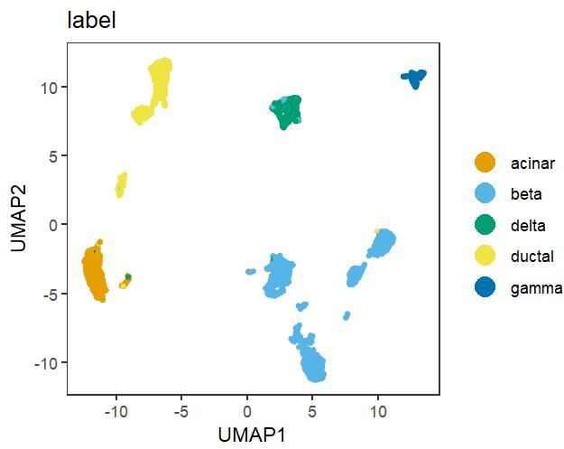

```r
# Note: dpi gets re-set by the styling code of this vignette, so this is
#   just a code example, but the plot won't be quite matched.
dittoDimPlot(sce, "label",
    do.raster = TRUE,
    raster.dpi = 300)
```

For `dittoHeatmap()`, where the plotting itself is handled externally, the control is a bit different and we rely on `?ComplexHeatmap::Heatmap`’s input for this. First, set `complex = TRUE` to have the heatmap rendered by ComplexHeatmap, then rasterization should be turned on by default when needed, but it can also be turned on manually with `use_raster = TRUE`.

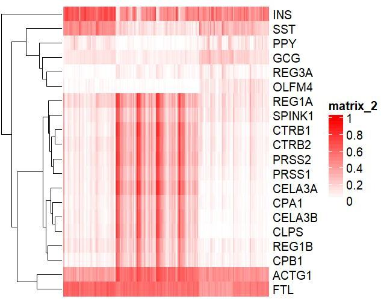

```r
dittoHeatmap(sce, genes, scaled.to.max = TRUE,
    complex = TRUE,
    use_raster = TRUE)
```

# References

Baron, Maayan, Adrian Veres, Samuel L. Wolock, Aubrey L. Faust, Renaud Gaujoux, Amedeo Vetere, Jennifer Hyoje Ryu, et al. 2016. “A Single-Cell Transcriptomic Map of the Human and Mouse Pancreas Reveals Inter- and Intra-Cell Population Structure.” *Cell Systems* 3 (4): 346–360.e4. https://doi.org/10.1016/j.cels.2016.08.011.

Wong, Bang. 2011. “Points of View: Color Blindness.” *Nature Methods* 8 (6): 441–41. https://doi.org/10.1038/nmeth.1618.